# Закономерности распределения двух линий трансмиссивного рака мидий BTN1 и BTN2

2024-10-31

## Пространственное распределение линий

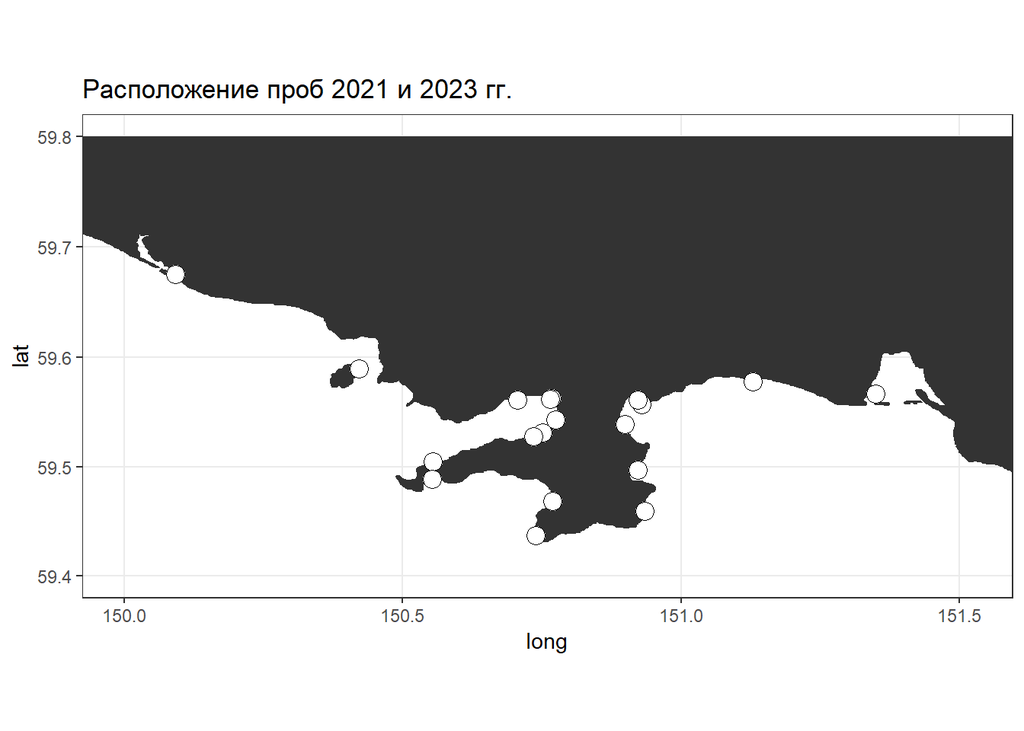

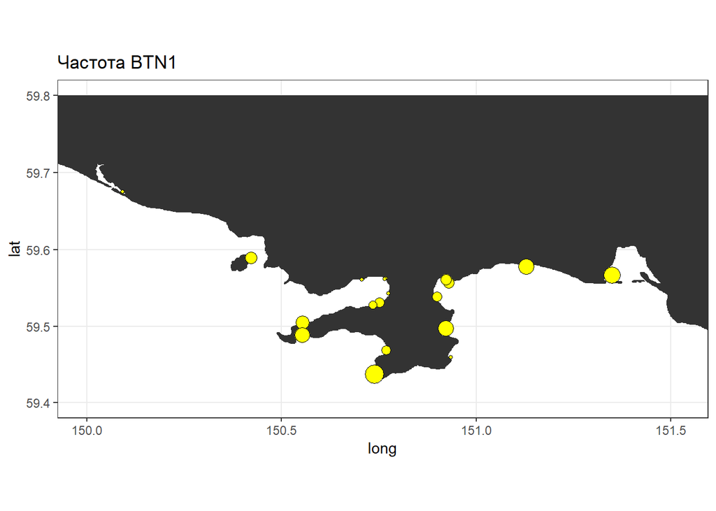

**Рисунок +.** Частота BTN1 на разных участках (объединенные данные 2021 и 2023 гг).

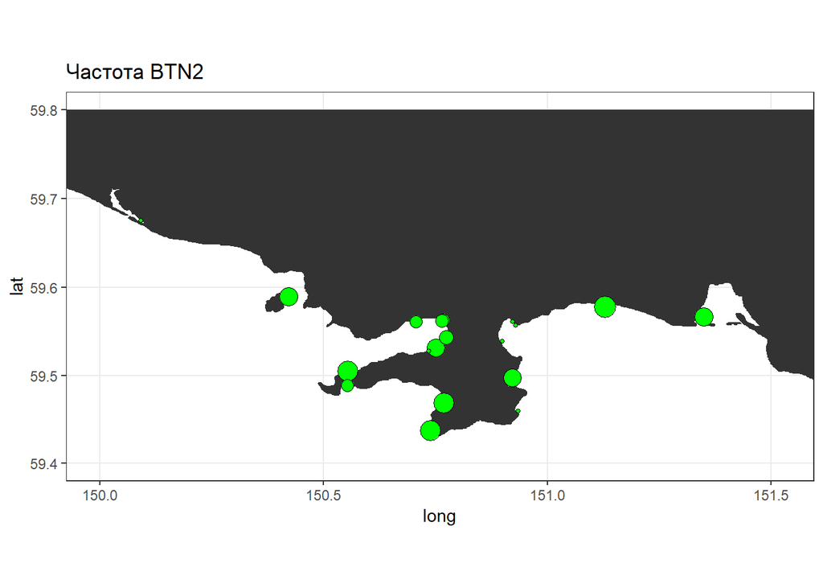

**Рисунок +.** Частота BTN2 на разных участках (объединенные данные 2021 и 2023 гг).

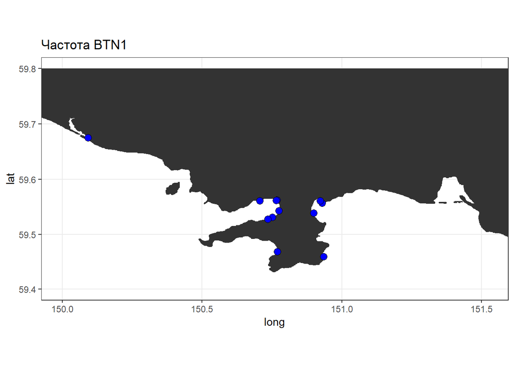

**Рисунок +.** Точки, где частота BTN1 **меньше**, чем в среднем по всему массиву данных (объединенные данные 2021 и 2023 гг)

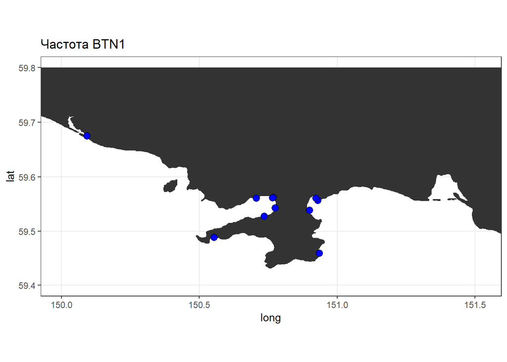

**Рисунок +.** Точки, где частота BTN2 **меньше**, чем в среднем по всему массиву данных (объединенные данные 2021 и 2023 гг)

Что видно

1. Непонятная пока рокировка между BTN1 и BTN2: BTN1 ощутимо присутствует на востоке перешейка, но малочислен на западе (район порта), а BTN2 наоборот, есть ощутимое пятно в районе порта (на западе), но он малочислен на востоке перешейка.
2. BTN2 распределен более равномерно, чем BTN1.
3. Есть какие-то волшебные точки, где раков мало. Куты?

При этом существует **положительная** корреляция между частотами двух линий

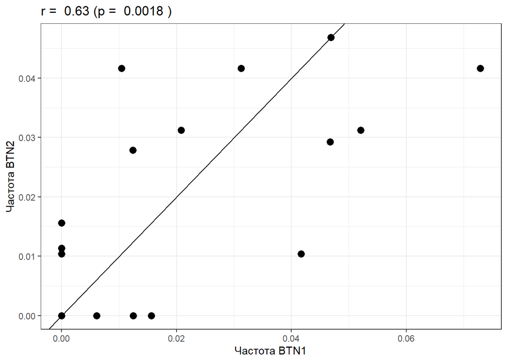

**Рисунок +.** Связь частот двух линий трансмиссивного рака

## Пространственная сегрегация линий?

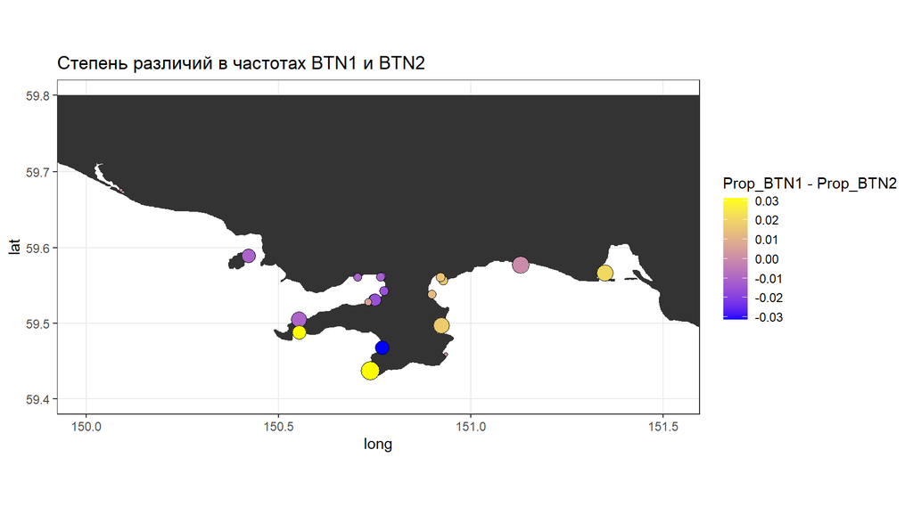

Это то же самое, но отдельно по годам

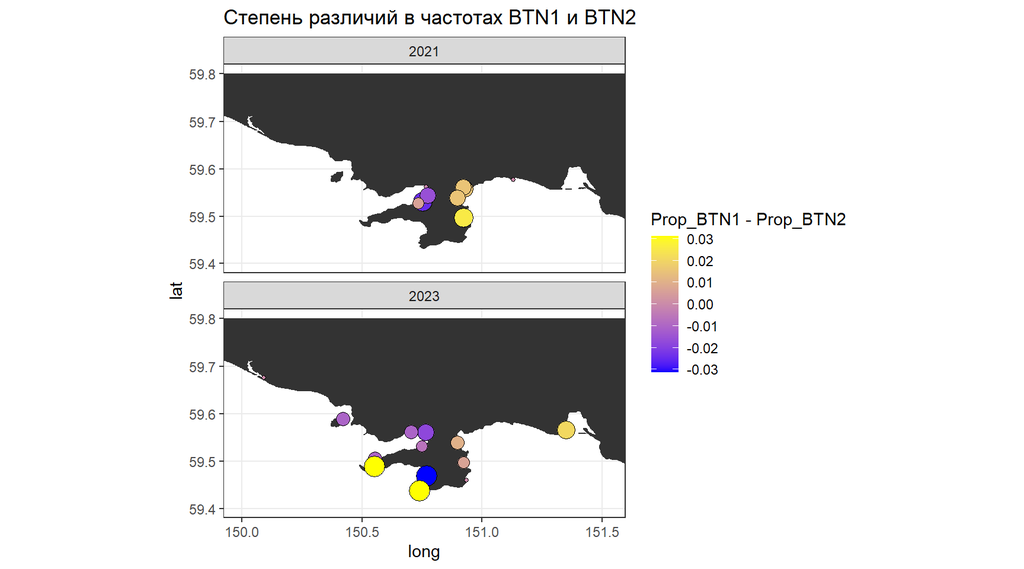

## Паттерны пространственного распределения линий

Для оценки паттернов пространственного распределений BTN1 и BTN2 был использован материал 2023 г. Поскольку в данный год проводили сборы так, что на каждой локации брали по несколько (2 или более) отдельных выборок, то появилась возможность оценить варьирование частот двух линий как масштабах нескольких метров (в пределах локаций), так и в масштабах километров (между локациями). Для оценки варьирования частот были введены две характеристики.

1. Варьирование частот в пределах локации (масштаб нескольких метров) оценивалась, как сумма квадратов отклонений частоты в выборке от среднего значения для данной локации:

$$SS_{within} = \Sigma\Sigma(p_{i,j} - \overline{p_i})^2$$

где $p_{i,j}$ - частота в j-й выборке в i-й локации, $\overline{p_i}$ - среднее значение частоты для i-й локации.

2. Варьирование частот между локациями (масштаб километров) оценивали, как сумму квадратов отклонений частоты в локации от среднего значения по всем локациям

$$SS_{between} = \Sigma(p_{i} - \overline{p_{total}})^2$$

где $p_{i}$ - частота в i-й локации, $\overline{p_{total}}$ - среднее значение частоты, для всех локаций.

Для оценки отклонения наблюдаемого пространственного паттерна от случайного была сформулирована нулевая модель, согласно которой частоты линий варьируют случайно в соответствии с биномиальным распределением с параметрами N и Prob, где N - количество мидий, собранных в отдельной выборке (в пределах локации), Prob- частота линии, оцененная по всему региону в 2023 г. Для характеристики распределения $SS_{within}$ и $SS_{between}$ при условии справедливости нулевой гипотезы было проведено 10^{4} симуляций. На каждом раунде симуляций для каждой из 49 отдельной совокупности с известным количеством мидий генерировалась численность моллюсков, которые должны бы были быть заражены BTN1 или BTN2. Далее на основе симулированных данных вычисляли $SS_{within}$ и $SS_{between}$. Поскольку эти две величины для каждой симуляции были сопряжены (На одном и том же материале одной симуляции вычисляли как $SS_{within}$, так и $SS_{between}$ ) то, в итоге, нулевое распределение получилось двумерным.

*NB!Это более правильный ход, чем генерация нулевых распределений для отдельных проб и сайтов по-отдельности.*

Для оценки p-value можно использовать долю тех симулированных точек, евклидово расстояние от которых до медианы нулевого распределения больше или равно расстоянию от медианы до фактически наблюдаемого соотношения $SS_{within}$ и $SS_{between}$.

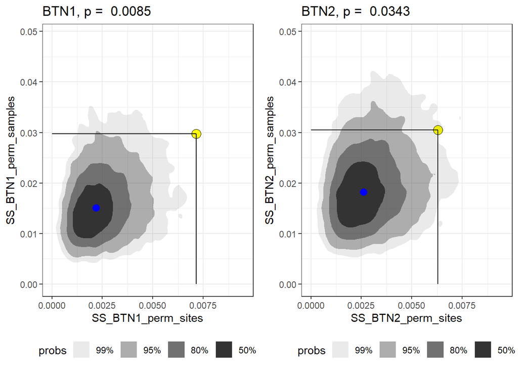

**Рисунок +.** Соотношение симулированных и наблюдаемых значений $SS_{within}$ и $SS_{between}$. Желтая точка - наблюдаемые значения, Синяя точка - медиана распределения значений, симулированных в соответствии с нулевой моделью. Контуры отражают перцентили симулированного распределения.

## Факторы, регулирующие распределеине BTN1 и BTN2

Для анализа связи частоты двух линий трансмиссивного рака и абиотическими факторами среды и популяционными параметрами была построена обобщенная аддитивная модель следующего вида.

$$P = b_0 + b_1Lin_{BTN2} + s(Dist_{port}|Lin) + s(fetch|Lin) + s(PC1|Lin)
+ s(N_{Large}|Lin) + s(OGP|Lin) + s(RND_{Sample}) + e$$

Доступные абиотические факторы

- $s(Dist_{port}|Lin)$ - непараметрическая сглаживающая функция, описывающая связь частоты с расстоянием до порта (вдоль береговой линии)
- $s(fetch|Lin)$ - непараметрическая сглаживающая функция, описывающая связь частоты со степенью открытости побережья

Доступные популяционные параметры

- $s(PC1|Lin)$ - непараметрическая сглаживающая функция, описывающая связь частоты с характеристиками размерной структуры поселений
- $s(N_{Large}|Lin)$ - непараметрическая сглаживающая функция, описывающая связь частоты с плотностью поселения мидий, входящих в размерный класс, для которого определяли наличие BTN
- $s(OGP|Lin)$ - непараметрическая сглаживающая функция, описывающая связь частоты со скоростью роста мидий в данной локации.
- $s(RND_{Sample})$ - Случайный фактор, определяющий варьирование, связанное с наличием нескольких выборок в пределах локации.
- $Lin$ - линия BTN (за базовый уровень взят BTN1)
- $e$ - остатки.

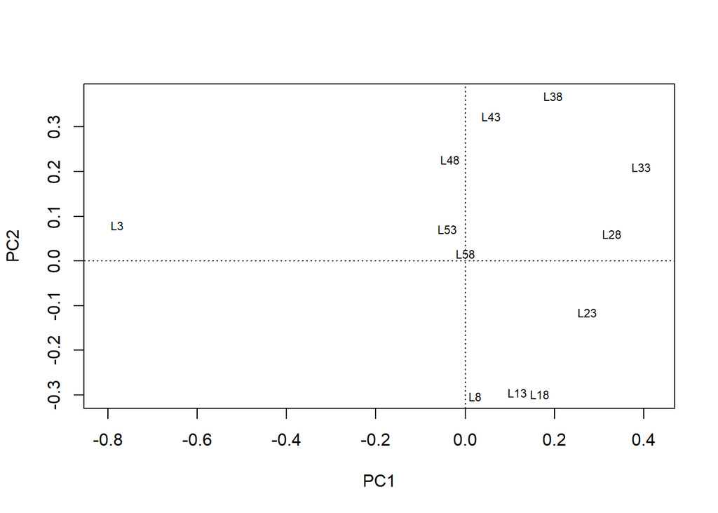

**Рисунок +.** Ординация размерных классов мидий в пространстве гдавных компоеннет

### Результаты

Параметры модели

```
## # A tibble: 11 × 5
##    term                             edf ref.df   statistic p.value
##    <chr>                          <dbl>  <dbl>       <dbl>   <dbl>
##  1 s(Dist_Port):LineageBTN1  1.00         1.00 7.75        0.00537
##  2 s(Dist_Port):LineageBTN2  2.66         3.09 4.81        0.196
##  3 s(fetch):LineageBTN1      1.00         1.00 4.76        0.0291
##  4 s(fetch):LineageBTN2      1.50         1.72 0.000000275 1
##  5 s(PC1):LineageBTN1        2.37         2.89 8.25        0.0296
##  6 s(PC1):LineageBTN2        1.39         1.65 1.78        0.418
##  7 s(N_Large):LineageBTN1    1.00         1.00 0.00507     0.943
##  8 s(N_Large):LineageBTN2    1.00         1.00 2.90        0.0884
##  9 s(OGP_sample):LineageBTN1 1.00         1.00 6.49        0.0109
## 10 s(OGP_sample):LineageBTN2 1.00         1.00 0.0706      0.791
## 11 s(Sample)                 0.00000662   1    0.00000565  0.285
```

### Визуализация модели

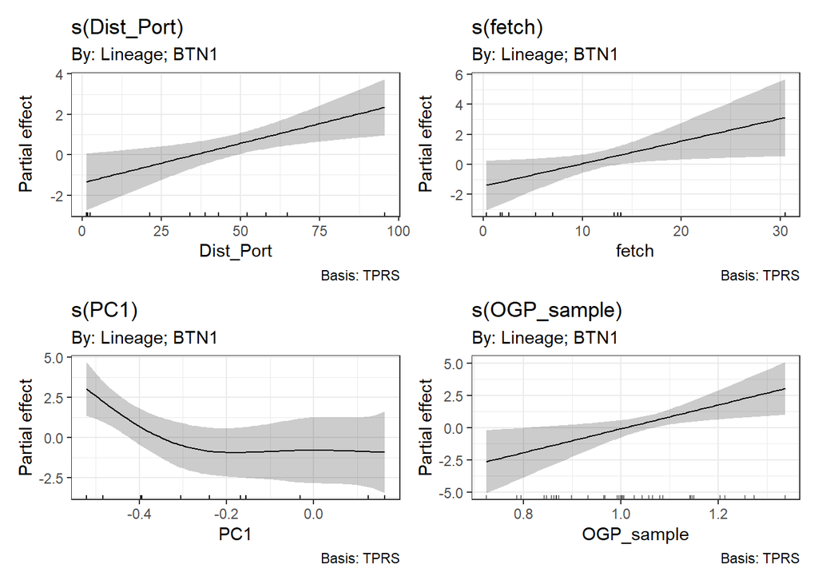

**Рисунок +.** Визулизацция модели

Что видно

1. Явных связей с изученными факторами у BTN2 нет.
2. BTN1 имеет повышенную частоту на значительном расстоянии от порта, при высокой открытости побережья, где моллюски растут быстрее. При этом более высокая частота BTN1 отмечается в тех локациях, где наблюдается бимодальная размерная структура (Отрицательные значения PC1), характеризующаяся высоким обилием молоди, сосуществующей с крупными мидиями.

## Заключение

1. Есть подозрение, что BTN2 неслучайно привязан к порту (см. карты). Возможно он ведет себя как инвазивный вид, живущий везде. Отсюда и его всесветное распределение.
2. BTN1 можно рассматривать, как “коренной” вид, имеющий устоявшиеся связи с параметрами среды и структурой поселения хозяина.
3. Положительная корреляция между частотами BTN1 и BTN2, возможно, свидетельствует о том, что вообще есть какие-то неблагоприятные для раков местообитания, где их частоты оказываются ниже, чем везде. Возможно это кутовые части заливов (низкая прибойность?)